# Untitled

박지은

2020 1 10

# 1-1 주어진 데이터는 1000개의 관측지 데이터입니다. 데이터를 불러오고 분포를 확인하ㅔ요. data<-read.csv(“https://git.io/v58i8”)

```r
data<-read.csv("https://git.io/v58i8")
head(data)
```

```
##          x
## 1 2.875601
## 2 2.896516
## 3 2.753752
## 4 2.922786
## 5 2.809089
## 6 3.100858
```

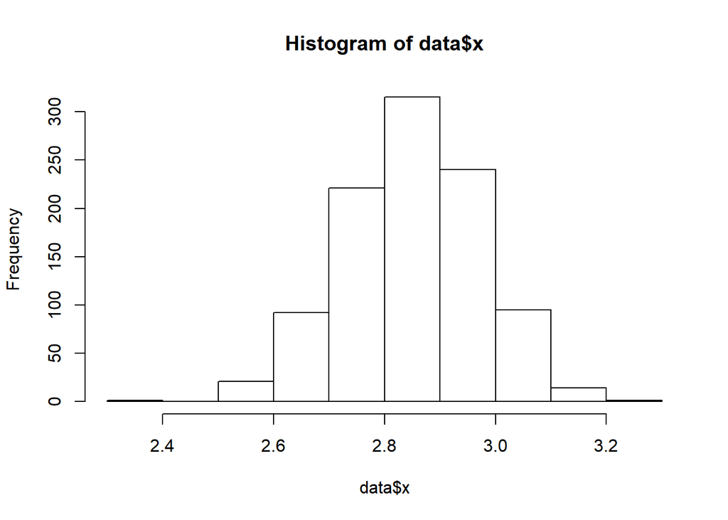

```r
hist(data$x)
```

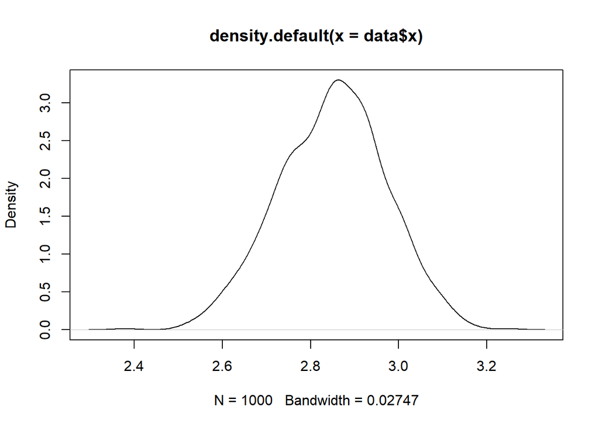

```r
plot(density(data$x))
```

# 1-2 자신이 생각했을때 분포에 적합한, loglikelihood function을 정의하세요.

```r
nll.normal <- function(data, par) {
  return(-sum(log(dnorm(data, mean=par[1], sd=par[2]))))

}
```

# 1-3 optim 함수를 사용해 loglikelihood function을 maxmize하는 mean과 sd 를 찾으세요.

```r
optim(par=c(1,0.1), fn=nll.normal, data=data$x)
```

```
## $par
## [1] 2.8494538 0.1214792
##
## $value
## [1] -689.2001
##
## $counts
## function gradient
##       85       NA
##
## $convergence
## [1] 0
##
## $message
## NULL
```

# 2-1번

## 다음의 분할표를 만들라.

```r
tab = matrix(c(509, 398, 116, 104),2,2)
tab
```

```
##      [,1] [,2]
## [1,]  509  116
## [2,]  398  104
```

# 2-2번

## 분할표를 통해 오즈비와 신뢰구간을 구하고 구한 오즈비를 사례대조연구와 코호트 연구에 맞게 해석하라.

```r
fit = glm(tab~c(1,0),family=binomial())
exp(coef(fit))
```

```
## (Intercept)     c(1, 0)
##    3.826923    1.146595
```

```r
exp(confint.default(fit))
```

```
##                 2.5 %   97.5 %
## (Intercept) 3.0839654 4.748867
## c(1, 0)     0.8533479 1.540615
```

#2-3번 ##위에서 만든 분할표를 토대로 사후세계에 대한 믿음이 성별과 독립관계인지를 알아보고자한다. ### 이들의 귀무가설과 대조가설을 설명하고, 95%신뢰수준하에서 검정하라

```r
chisq.test(tab, correct =FALSE)
```

```
##
##  Pearson's Chi-squared test
##
## data:  tab
## X-squared = 0.82458, df = 1, p-value = 0.3638
```

#2-4번 ###한 심리학자는 여성이 남성보다 사후세계를 더 많이 믿는다고 생각하고 이를 검정해보고자 한다 ### 이를 검정하기 위한 귀무가설과 대조가설을 설명하고, 95%의 신뢰수준하에 검정하여라

```r
chisq.test(tab, correct=FALSE)
```

```
##
##  Pearson's Chi-squared test
##
## data:  tab
## X-squared = 0.82458, df = 1, p-value = 0.3638
```

#4-5 ###두 검정의 결과가 동일한가? >같은 결과를 가진다. 두 검정은 같은 통계량을 가짐에도 다른 가설을 가질 뿐이어서 동일하다.